# Lab 2 Team

Meredith Tucker, Mike Zaino

2/5/2020

1. What is the overall number of chocolate bars rated?

```r
choco <- read.csv("https://xdaiisu.github.io/ds202materials/hwlabs/choco.csv")
head(choco)
```

```
##    Company Specific.Bean.Origin  REF Review.Date Cocoa.Pct
## 1 A. Morin          Agua Grande 1876        2016        63
## 2 A. Morin                Kpime 1676        2015        70
## 3 A. Morin               Panama 1011        2013        70
## 4 A. Morin           Madagascar 1011        2013        70
## 5 A. Morin               Brazil 1011        2013        70
## 6 A. Morin             Equateur 1011        2013        70
##   Company.Location Rating Bean.Type Broad.Bean.Origin
## 1           France   3.75                    Sao Tome
## 2           France   2.75                        Togo
## 3           France   2.75                      Panama
## 4           France   3.00   Criollo        Madagascar
## 5           France   3.25                      Brazil
## 6           France   3.75                     Ecuador
```

```r
length(choco$Rating)
```

```
## [1] 1852
```

There are 1852 chocolate bars that are rated in the data set.

2. How does the number of ratings depend on the year? Draw a bar chart of the number of reports.

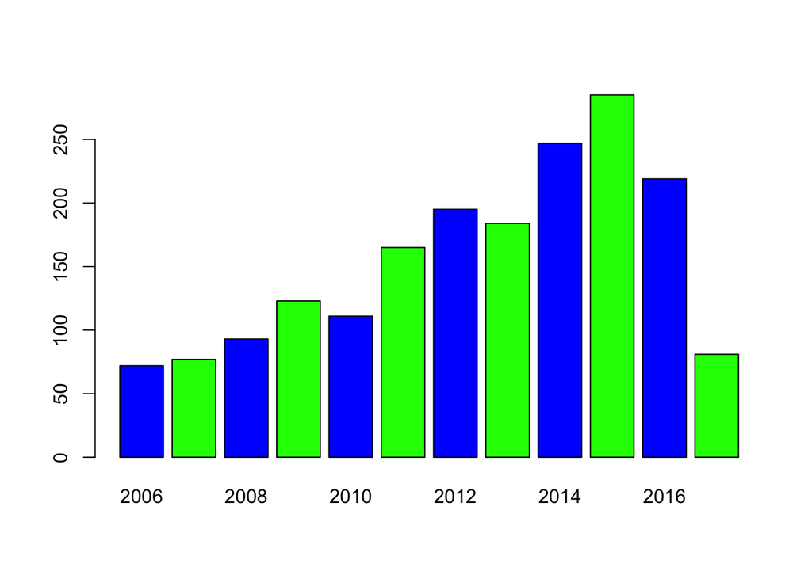

```r
choco$Review.Date <- as.factor(choco$Review.Date)

YearTotal <- c(72, 77,93,123,111,165, 195,184, 247,285,219,81)
YearNames <- c("2006", "2007", "2008", "2009", '2010', '2011', '2012', '2013', '2014', '2015', '2016', '2017')

barplot(YearTotal,names.arg = YearNames, col=c('blue', 'green'))
```

3. Which are the three locations with the most ratings? How do ratings compare across these company locations?

```r
loco <- choco$Company.Location
names(loco) <- choco$Company.Location
numloco <- summary(loco)
biggest3 <- sort(numloco, decreasing = TRUE)[1:3]
biggest3
```

```
## U.S.A. France Canada
##    787    158    132
```

```r
USA <- choco[choco$Company.Location == "U.S.A.", ]
France <- choco[choco$Company.Location == "France", ]
Canada <- choco[choco$Company.Location == "Canada", ]

table <- c(mean(USA$Rating),mean(France$Rating),mean(Canada$Rating))
names(table) <- c("USA","France", "Canada")
table
```

```
##      USA   France   Canada
## 3.162325 3.253165 3.312500
```

The three countries that have the most number of ratings all have about the same average rating. Canada has the highest rating with approximently 3.31. Then France with 3.25, and then USA with 3.16.

4. Brainstorm and write down an interesting question that can be answer from the dataset. The question should not duplicate the questions above.

Question: Which company has the most number of ratings?

5. Answer the question from the dataset.

```r
head(sort(summary(choco$Company), decreasing=T))
```

```
##  (Other)     Soma   Bonnat   Fresco   Pralus A. Morin
##      767       47       27       26       25       23
```

Without including the unnamed companies, the largest company reviewed was Soma. This was followed by Bonnat and Fresco.

6. Write one paragraph commenting on the workflow

We worked dilgently together and used our resources to find the best methods to create solutions. When we started a new problem we brainstormed ideas of what to do. From there we both worked on our brainstorming ideas each on our laptops and then combined the end product. If it would not work, we then used trial and error to fix the mistake. Once we found the answer, we coded into the team.Rmd file. We did not bother to make it look perfect as the second person could edit it.